# FA6

Aldwin Benidict Montilla

2026-09-20

*GitHub link:* https://github.com/aldwinmontilla661-dot/Aldwin-Benidict-Montilla/tree/main/APM1110-FA6

# I. **Geometric Distribution**

### Provide an R code for the geometric distribution. The geometric distribution is a prob-ability distribution that models the number of trials required to achieve the first success in a sequence of Bernoulli trials, where each trial has a constant probability of success.

## 1. Set the probability of success: p ← 0.2

```r
p <- 0.2
```

## 2. Generate 1000 random variables from the geometric distribution.

```r
# We will have to add 1 because rgeom() counts failures, but we want the total number of trials.
set.seed(42) # Optional: ensures identical results every time you run it
x <- rgeom(1000, prob = p) + 1
```

## 3. Calculate basic statistics:

```r
mean_x <- mean(x)
var_x  <- var(x)
sd_x   <- sd(x)
```

## 4. Print the results in item 3.

```r
cat("Number of trials required to achieve first success:\n",
    sprintf("• Mean: %.2f\n", mean_x),
    sprintf("• Variance: %.2f\n", var_x),
    sprintf("• Standard deviation: %.2f\n", sd_x))
```

```
## Number of trials required to achieve first success:
##  • Mean: 5.16
##  • Variance: 21.69
##  • Standard deviation: 4.66
```

## 5. Plot the histogram of the results.

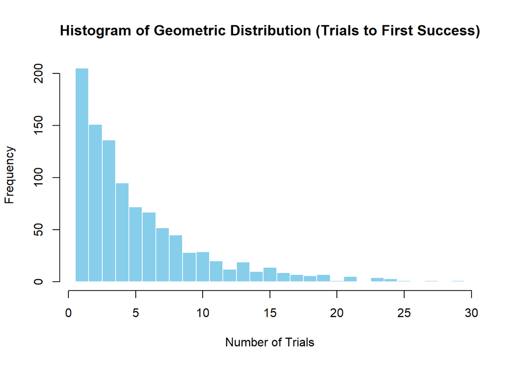

```r
hist(x,
     breaks = seq(0.5, max(x) + 0.5, by = 1),
     col = "skyblue",
     border = "white",
     main = "Histogram of Geometric Distribution (Trials to First Success)",
     xlab = "Number of Trials",
     ylab = "Frequency")
```

# II. Hypergeometric Distribution

### Consider a plant manufacturing IC chips of which 10% are expected to be defective. The chips are packed in boxes for export. Before transportation, a sample is drawn from each box. Estimate the probability that the sample contains more than 10% defectives, when:

## 1. A sample of 10 is selected from a box of 40;

```r
# Population size.
N = 40

# Defective chips in the population.
K = 0.1 * N #10% of 40 (population).

# Non-defective chips in population.
non_def = N - K #population minus the defective chips.

# Sample size.
n = 10

# We want P(X > 1), which is 1 - P(X <= 1).
# We will use the built-in hypergeometric distribution function (phyper) to calculate the exact probabilities for box sizes.
# R's phyper(x, K, N-K, n) calculates P(X <= x).

prob_box_40 <- 1 - phyper(1, m = K, n = non_def, k = 10)
```

### Print the results

```r
cat("Hypergeometric Distribution Probabilities (Sample > 10% Defective):\n",
    sprintf("1. Box of 40 chips:   %.4f (or %.2f%%)\n", prob_box_40, prob_box_40 * 100))
```

```
## Hypergeometric Distribution Probabilities (Sample > 10% Defective):
##  1. Box of 40 chips:   0.2559 (or 25.59%)
```

## 2. A sample of 10 is selected from a box of 5000.

```r
# Population size.
N = 5000

# Defective chips in the population.
K = 0.1 * N #10% of 5000 (population).

# Non-defective chips in population.
non_def = N - K #population minus the defective chips.

# Sample size.
n = 10

# We will use the same method of calculation for the first scneario.
prob_box_5000 <- 1 - phyper(1, m = K, n = non_def, k = 10)
```

### Print the results

```r
cat("Hypergeometric Distribution Probabilities (Sample > 10% Defective):\n",
    sprintf("2. Box of 5000 chips: %.4f (or %.2f%%)\n", prob_box_5000, prob_box_5000 * 100))
```

```
## Hypergeometric Distribution Probabilities (Sample > 10% Defective):
##  2. Box of 5000 chips: 0.2639 (or 26.39%)
```

## Interpretation

### In the box of 40, every time you pull out a chip, you significantly alter the remaining pool. If you pull a clean chip, the concentration of defective chips left behind goes up. This dependency “dampens” extreme variance, making the probability of pulling multiple defectives slightly lower (25.59%).

### In the box of 5000, the pool is so massive that drawing 10 chips barely modifies the remaining ratio. The trials act almost completely independent of one another. As a result, the probability rises slightly to 26.39%, which perfectly converges toward a standard Binomial Distribution calculation ($B(10, 0.10)$).